# OCN683_homework_1

kelli konicek

2025-02-14

Dear Dr. Edwards, I hope this is my worst homework. Or, at least, I hope this *isn’t* my best homework.

# Load Libraries

```r
library(tidyverse)
library(here)
library(ggeffects)
library(GGally)
library(effects)
library(ggResidpanel)
library(car)
```

# Upload Data, remove species not mentioned in prompt(?)

I am a little concerned I am making a bad mistake, but the ’oma’o and the elepaio that weren’t mentioned in the prompt and also do not have very many observations, so I am going to assume they are left out on purpose.

```r
raw <- read_csv(here("week_1","data","foraging.height.edit.csv")) %>%
  filter(SPECIES != "OMAO") %>%
  filter(SPECIES != "HAEL") #I don't know why my original code didn't work and I am too tired to fix my putrid whoopsie
```

```
## ──────────────────────────────────────────────────────── Delimiter: "," chr
## (6): SPECIES, Kipuka, Rat_Removal, DATE, OBSERVER, dietary.grouping dbl (6):
## ...1, Area_ha, Elevation_m, Year, tot.arth.bm, foraging.ht.m
```

# 1)

## How many observations are there of each bird species in each experimental treatment?

```r
raw %>%
  count(SPECIES, Rat_Removal, sort = TRUE)
```

```
## # A tibble: 8 × 3
##   SPECIES Rat_Removal     n
##   <chr>   <chr>       <int>
## 1 APAP    untreated     188
## 2 APAP    treated       131
## 3 HAAM    treated        47
## 4 IIWI    untreated      43
## 5 HAAM    untreated      42
## 6 IIWI    treated        30
## 7 JAWE    treated        16
## 8 JAWE    untreated       9
```

## Make a boxplot or violinplot to show the distribution of foraging heights of each bird species in each experimental treatment.

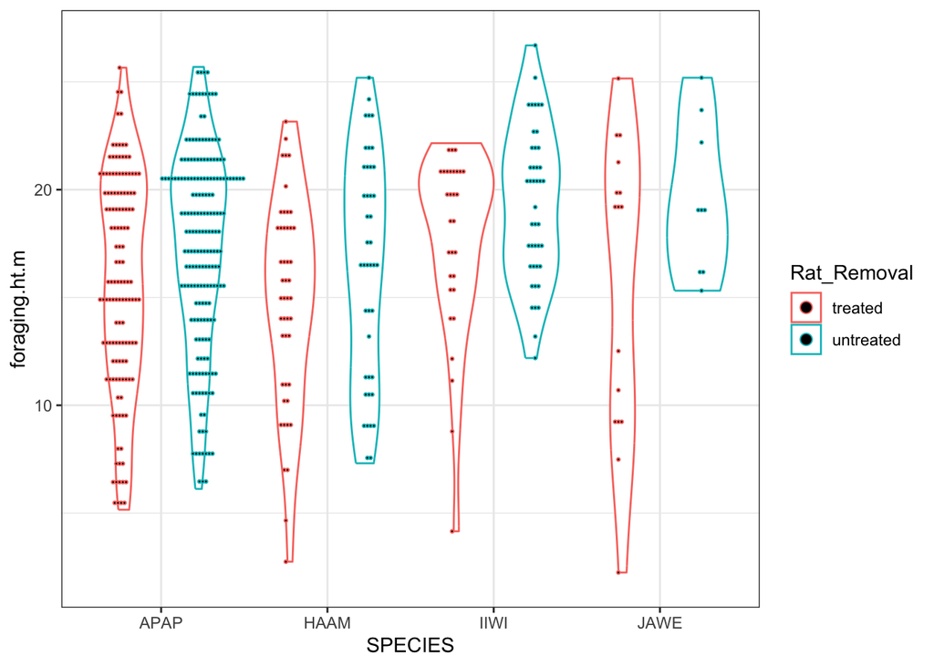

```r
boxplot1 <- raw %>%
  ggplot(aes(x = SPECIES, y = foraging.ht.m, color = Rat_Removal))+
  geom_violin() +
  geom_dotplot(dotsize= 0.2, binaxis='y', stackdir='center',
                 position=position_dodge(1), binwidth = .75) +
  theme_bw()
  boxplot1
```

## What have you learned so far?